# Population Health Impacts Estimation: Preterm Birth and Black Carbon Exposure

Kay Royo

2024-08-27

## **Summary**

This project evaluates the relationship between air pollution, specifically black carbon, and preterm birth in urban areas of California, as well as differences in this relationship by race. The black carbon pollutant is a type of fine particulate matter that is released from diesel engines, wood heating, and wildfires that has been linked to adverse birth outcomes.

Using data from 5,000 birth certificates in San Jose and Oakland between 2013 and 2015, this analysis aims to estimate the potential impact of reducing black carbon exposure on the risk of preterm births. The black carbon levels in this data were measured at the block level through Google vehicles that monitored the pollutant over the study period. After consulting with environmental health experts, the analysis will control for potential confounders between black carbon levels and preterm births, including maternal age, maternal education, infant’s sex assigned at birth, and gestational weight. In this analysis, the key measure of association is the risk difference, which will help determine the proportion of preterm births that could be prevented by reducing black carbon levels from their current level to below 0.20 milligrams grams per cubic meter.

The primary research question is: *Would reducing the levels of black carbon to below* $0.20 \ mg/m^3$ *reduce the risk of preterm birth? If so, approximately how many preterm births could potentially be prevented?*

## **Counterfactual**

Based on the research question above, the counterfactual question can be defined as: *What would be the effect on risk of preterm birth if the black carbon concentration was reduced to <0.20 milligrams per cubic meter for all residents of San Jose and Oakland, compared to the current level of black carbon?*

Counterfactual scenario 1: Residents are exposed to less than $0.20 \ mg/m^3$ of black carbon.

Counterfactual scenario 2: Residents are exposed to current levels of black carbon.

## **Data Exploration**

```r
# Load dataset
air_pollution <- as.data.frame(read.csv("pollution_study.csv"))
```

Variable definitions:

- `maternal_age`: mother’s age in years
- `education`: mother’s highest educational attainment (1 = some high school, 2 = high school graduate, 3 = some college, 4 = college graduate, 5 = master’s degree or higher)
- `infant_sex`: 0 = female, 1 = male
- `birth_weight`: gestational weight in pounds
- `preterm`: 0 = full-term (37+ weeks), 1 = pre-term (<37 weeks)
- `race`: AI = American Indian or Alaska Native, AS = Asian, BL = Black or African American, NHPI = Native Hawaiian or other Pacific Islander, WH = White, HIS = Hispanic of any race
- `black_carbon`: 0 = <$0.20 \ \mu g/m^3$, 1 = >$0.20 \ \mu g/m^3$

```r
# Data summary
print(dfSummary(air_pollution, plain.ascii  = TRUE,  headings     = FALSE,
          style        = "multiline",
          graph.col    = FALSE,
          valid.col    = FALSE, silent = TRUE, varnumbers = FALSE, display.labels = TRUE, footnote = ''), method = 'pander',headings = FALSE,
          bootstrap.css = FALSE)
```

```
##
## --------------------------------------------------------------------
## Variable       Stats / Values         Freqs (% of Valid)   Missing
## -------------- ---------------------- -------------------- ---------
## maternal_age   Mean (sd) : 27.5 (5)   34 distinct values   0
## [integer]      min < med < max:                            (0.0%)
##                12 < 27 < 45
##                IQR (CV) : 7 (0.2)
##
## education      Mean (sd) : 3 (1.3)    1 :  747 (14.9%)     0
## [integer]      min < med < max:       2 : 1053 (21.1%)     (0.0%)
##                1 < 3 < 5              3 : 1502 (30.0%)
##                IQR (CV) : 2 (0.4)     4 :  938 (18.8%)
##                                       5 :  760 (15.2%)
##
## infant_sex     Min  : 0               0 : 2543 (50.9%)     0
## [integer]      Mean : 0.5             1 : 2457 (49.1%)     (0.0%)
##                Max  : 1
##
## birth_weight   Mean (sd) : 7 (1)      65 distinct values   0
## [numeric]      min < med < max:                            (0.0%)
##                3.7 < 7 < 10.1
##                IQR (CV) : 1.4 (0.1)
##
## race           1. AI                   106 ( 2.1%)         0
## [character]    2. AS                   883 (17.7%)         (0.0%)
##                3. BL                   975 (19.5%)
##                4. HIS                 1316 (26.3%)
##                5. NHPI                 195 ( 3.9%)
##                6. WH                  1525 (30.5%)
##
## black_carbon   Min  : 0               0 : 4012 (80.2%)     0
## [integer]      Mean : 0.2             1 :  988 (19.8%)     (0.0%)
##                Max  : 1
##
## preterm        Min  : 0               0 : 4477 (89.5%)     0
## [integer]      Mean : 0.1             1 :  523 (10.5%)     (0.0%)
##                Max  : 1
## --------------------------------------------------------------------
```

```r
# Cross-tabulation: preterm births (outcome) and black carbon (exposure)
with(air_pollution,
     print(ctable(x = factor(black_carbon),
                  y = factor(preterm),
                  prop     = 'n',
                  chisq = TRUE,
                  OR    = TRUE,
                  RR    = TRUE,
                  totals   = FALSE,
                  headings = FALSE),
            method = "pander")
)
```

```
##
## ---------------------- ----------------- ------ -----
##                          factor(preterm)      0     1
##   factor(black_carbon)
##                      0                     3669   343
##                      1                      808   180
## ---------------------- ----------------- ------ -----
##
## ----------------------------
##  Chi.squared   df   p.value
## ------------- ---- ---------
##    78.1093     1       0
## ----------------------------
##
## ----------------------------------
##  Odds Ratio   Lo - 95%   Hi - 95%
## ------------ ---------- ----------
##     2.38        1.96       2.90
## ----------------------------------
##
## ----------------------------------
##  Risk Ratio   Lo - 95%   Hi - 95%
## ------------ ---------- ----------
##     1.12        1.08       1.15
## ----------------------------------
```

Since the risk ratio is 1.12, it means that there is a positive association between preterm birth and black carbon exposure and the risk of preterm birth is higher in the group exposed to high levels of black carbon than the group exposed to low levels.

## **Marginal Standardization**

### Model Fitting

In the fitted logistic regression model below, `preterm` is the binary outcome and `black_carbon` is the exposure. This regression model controls for `maternal_age`, `education`, `infant_sex` and `birth_weight`.

```r
fit.pollution <- glm(preterm ~ black_carbon + maternal_age + factor(education) + infant_sex + birth_weight, data = air_pollution, family = 'binomial')

summary(fit.pollution)
```

```
##
## Call:
## glm(formula = preterm ~ black_carbon + maternal_age + factor(education) +
##     infant_sex + birth_weight, family = "binomial", data = air_pollution)
##
## Coefficients:
##                     Estimate Std. Error z value Pr(>|z|)
## (Intercept)        -2.133956   0.438139  -4.871 1.11e-06 ***
## black_carbon        0.877808   0.100136   8.766  < 2e-16 ***
## maternal_age       -0.006700   0.009419  -0.711   0.4769
## factor(education)2  0.119054   0.162732   0.732   0.4644
## factor(education)3  0.151288   0.152087   0.995   0.3199
## factor(education)4  0.098803   0.167249   0.591   0.5547
## factor(education)5  0.273037   0.170746   1.599   0.1098
## infant_sex         -0.212143   0.093870  -2.260   0.0238 *
## birth_weight       -0.012435   0.046453  -0.268   0.7889
## ---
## Signif. codes:  0 '***' 0.001 '**' 0.01 '*' 0.05 '.' 0.1 ' ' 1
##
## (Dispersion parameter for binomial family taken to be 1)
##
##     Null deviance: 3350.7  on 4999  degrees of freedom
## Residual deviance: 3272.6  on 4991  degrees of freedom
## AIC: 3290.6
##
## Number of Fisher Scoring iterations: 5
```

```r
tidy(fit.pollution, exponentiate=TRUE, conf.int=TRUE)
```

```
## # A tibble: 9 × 7
##   term               estimate std.error statistic  p.value conf.low conf.high
##   <chr>                 <dbl>     <dbl>     <dbl>    <dbl>    <dbl>     <dbl>
## 1 (Intercept)           0.118   0.438      -4.87  1.11e- 6   0.0500     0.278
## 2 black_carbon          2.41    0.100       8.77  1.85e-18   1.97       2.92
## 3 maternal_age          0.993   0.00942    -0.711 4.77e- 1   0.975      1.01
## 4 factor(education)2    1.13    0.163       0.732 4.64e- 1   0.821      1.55
## 5 factor(education)3    1.16    0.152       0.995 3.20e- 1   0.867      1.58
## 6 factor(education)4    1.10    0.167       0.591 5.55e- 1   0.797      1.54
## 7 factor(education)5    1.31    0.171       1.60  1.10e- 1   0.941      1.84
## 8 infant_sex            0.809   0.0939     -2.26  2.38e- 2   0.673      0.972
## 9 birth_weight          0.988   0.0465     -0.268 7.89e- 1   0.902      1.08
```

### Pseudo-population

```r
# 2 "pseudo-populations" based on counterfactual
pollution_current <- air_pollution #%>% mutate(black_carbon = 1)
pollution_low <-  air_pollution %>% mutate(black_carbon = 0)
```

```r
# Examine confounder distributions in each "pseudo-population"
summary(pollution_current$maternal_age)
```

```
##    Min. 1st Qu.  Median    Mean 3rd Qu.    Max.
##    12.0    24.0    27.0    27.5    31.0    45.0
```

```r
summary(pollution_low$maternal_age)
```

```
##    Min. 1st Qu.  Median    Mean 3rd Qu.    Max.
##    12.0    24.0    27.0    27.5    31.0    45.0
```

```r
proportions(table(pollution_current$education))
```

```
##
##      1      2      3      4      5
## 0.1494 0.2106 0.3004 0.1876 0.1520
```

```r
proportions(table(pollution_low$education))
```

```
##
##      1      2      3      4      5
## 0.1494 0.2106 0.3004 0.1876 0.1520
```

```r
proportions(table(pollution_current$infant_sex))
```

```
##
##      0      1
## 0.5086 0.4914
```

```r
proportions(table(pollution_low$infant_sex))
```

```
##
##      0      1
## 0.5086 0.4914
```

```r
summary(pollution_current$birth_weight)
```

```
##    Min. 1st Qu.  Median    Mean 3rd Qu.    Max.
##   3.700   6.300   7.000   7.008   7.700  10.100
```

```r
summary(pollution_low$birth_weight)
```

```
##    Min. 1st Qu.  Median    Mean 3rd Qu.    Max.
##   3.700   6.300   7.000   7.008   7.700  10.100
```

```r
# Obtain predictions for each of these new "pseudo-populations"
pred_pollution_current <- predict(fit.pollution, newdata=pollution_current, type="response")
pred_pollution_low <- predict(fit.pollution, newdata=pollution_low, type="response")
```

### Average Risk

```r
# Calculate average risk in each population
p.poll.current <- mean(pred_pollution_current)
p.poll.low <- mean(pred_pollution_low)
```

### Measure of association: Risk difference

```r
R.1 <- p.poll.low
R.0 <- p.poll.current

round(R.1 - R.0, 3) # Risk difference of low vs. current pollution
```

```
## [1] -0.019
```

### CI estimation using bootstrapping

```r
# Create indx object which counts the number of observations in your observed dataset
indx<- nrow(air_pollution)

# Assign the "air_pollution" dataset to the object "data"
data<- air_pollution

# Define a function to carry out analysis on re-sampled version of dataset
stan.RD <- function(data, indx){
  data.samp <- data[indx,]

  # Fit model on resampled data:
  fit.pollution.boot <- glm(preterm ~ black_carbon + maternal_age +
                              factor(education) + infant_sex + birth_weight,
                    data = data, family = "binomial")

  # Copy resampled data and modify exposure under each scenario:
  data.samp.current <- data.samp
  data.samp.low <- data.samp |> mutate(black_carbon = 0)

  # Obtain predictions under each of these new "pseudo-populations"
  pred.current <- predict(fit.pollution.boot, newdata=data.samp.current, type="response")
  pred.low <- predict(fit.pollution.boot, newdata=data.samp.low, type="response")

  # Calculate overall risk in each population:
  R.1 <- mean(pred.low)
  R.0 <- mean(pred.current)

  # Estimate measures of association:
  return(R.1 - R.0) # standardized RD
}

# Pass the function to the boot() command to generate samples of estimates
n.cores <- parallel::detectCores() - 1 # use 1 less than you have
set.seed(123) # Specifies where the random number generator starts
boot.RD <- boot(data, stan.RD, R=10000, parallel="multicore", ncpus=n.cores) # Use this version for Mac or Linux
# boot.RD <- boot(data, stan.RD, R=10000, parallel="snow", ncpus=n.cores) # Use this version for Windows
# boot.RD <- boot(data, stan.RD, R=1000, parallel="multicore") # use this version for single-core

boot.RD # Note original point estimate
```

```
##
## ORDINARY NONPARAMETRIC BOOTSTRAP
##
##
## Call:
## boot(data = data, statistic = stan.RD, R = 10000, parallel = "multicore",
##     ncpus = n.cores)
##
##
## Bootstrap Statistics :
##        original       bias     std. error
## t1* -0.01922618 2.997703e-06 0.0005474867
```

```r
boot.ci(boot.RD, type="perc") # 95% percentile-based CI
```

```
## BOOTSTRAP CONFIDENCE INTERVAL CALCULATIONS
## Based on 10000 bootstrap replicates
##
## CALL :
## boot.ci(boot.out = boot.RD, type = "perc")
##
## Intervals :
## Level     Percentile
## 95%   (-0.0203, -0.0182 )
## Calculations and Intervals on Original Scale
```

```r
# Save output
boot.RD.total <- boot.RD
boot.RD.CI.total <- boot.ci(boot.RD, type="perc")
```

### Interpretation

The estimated risk difference (RD) is -0.019 (95% CI: -0.0203 to -0.0182). Hence, reducing the levels of black carbon from current levels to <$0.20 \ mg/m^3$ would result in a reduction of approximately 2 fewer preterm births per 100 births.

## **Race and ethnicity**

This section focused on answering the question: are there differences in the relationship between black carbon and preterm birth by racial group? Which groups would benefit most and least from reductions in black carbon?

```r
# Subset population by race and ethnicity
ai_pop <- filter(air_pollution, race == "AI") # Filter to American Indian & Alaska Native population
as_pop <- filter(air_pollution, race == "AS") # Filter to Asian population
bl_pop <- filter(air_pollution, race == "BL") # Filter to Black population
nhpi_pop <- filter(air_pollution, race == "NHPI") # Filter to Native Hawaiian and Pacific Islander population
wh_pop <- filter(air_pollution, race == "WH") # Filter to White population
his_pop <- filter(air_pollution, race == "HIS") # Filter to Black population
```

For this analysis, bootstrapping is directly used for each group to obtain the risk difference.

### American Indian & Alaska Native

```r
# Create new indx and data object
indx<- nrow(ai_pop)
data <- ai_pop

set.seed(123) # Specifies where the random number generator starts
boot.RD <- boot(data, stan.RD, R=10000, parallel="multicore", ncpus=n.cores) # Use this version for Mac or Linux
# boot.RD <- boot(data, stan.RD, R=10000, parallel="snow", ncpus=n.cores) # Use this version for Windows
# boot.RD <- boot(data, stan.RD, R=1000, parallel="multicore") # use this version for single-core

boot.RD # Note original point estimate
```

```
##
## ORDINARY NONPARAMETRIC BOOTSTRAP
##
##
## Call:
## boot(data = data, statistic = stan.RD, R = 10000, parallel = "multicore",
##     ncpus = n.cores)
##
##
## Bootstrap Statistics :
##        original        bias    std. error
## t1* -0.03552645 -1.451861e-05 0.007674062
```

```r
boot.ci(boot.RD, type="perc") # 95% percentile-based CI
```

```
## BOOTSTRAP CONFIDENCE INTERVAL CALCULATIONS
## Based on 10000 bootstrap replicates
##
## CALL :
## boot.ci(boot.out = boot.RD, type = "perc")
##
## Intervals :
## Level     Percentile
## 95%   (-0.0513, -0.0214 )
## Calculations and Intervals on Original Scale
```

```r
# Save output to environment
boot.RD.ai <- boot.RD
boot.RD.CI.ai <- boot.ci(boot.RD, type="perc")
```

### Asian

```r
# Create new indx and data object
indx<- nrow(as_pop)
data <- as_pop

set.seed(123) # Specifies where the random number generator starts
boot.RD <- boot(data, stan.RD, R=10000, parallel="multicore", ncpus=n.cores) # Use this version for Mac or Linux
# boot.RD <- boot(data, stan.RD, R=10000, parallel="snow", ncpus=n.cores) # Use this version for Windows
# boot.RD <- boot(data, stan.RD, R=1000, parallel="multicore") # use this version for single-core

boot.RD # Note original point estimate
```

```
##
## ORDINARY NONPARAMETRIC BOOTSTRAP
##
##
## Call:
## boot(data = data, statistic = stan.RD, R = 10000, parallel = "multicore",
##     ncpus = n.cores)
##
##
## Bootstrap Statistics :
##         original        bias    std. error
## t1* -0.008164627 -9.728905e-06 0.000681185
```

```r
boot.ci(boot.RD, type="perc") # 95% percentile-based CI
```

```
## BOOTSTRAP CONFIDENCE INTERVAL CALCULATIONS
## Based on 10000 bootstrap replicates
##
## CALL :
## boot.ci(boot.out = boot.RD, type = "perc")
##
## Intervals :
## Level     Percentile
## 95%   (-0.0095, -0.0069 )
## Calculations and Intervals on Original Scale
```

```r
# Save output to environment
boot.RD.as <- boot.RD
boot.RD.CI.as <- boot.ci(boot.RD, type="perc")
```

### Black or African American

```r
# Create new indx and data object
indx<- nrow(bl_pop)
data <- bl_pop

set.seed(123) # Specifies where the random number generator starts
boot.RD <- boot(data, stan.RD, R=10000, parallel="multicore", ncpus=n.cores) # Use this version for Mac or Linux
# boot.RD <- boot(data, stan.RD, R=10000, parallel="snow", ncpus=n.cores) # Use this version for Windows
# boot.RD <- boot(data, stan.RD, R=1000, parallel="multicore") # use this version for single-core

boot.RD # Note original point estimate
```

```
##
## ORDINARY NONPARAMETRIC BOOTSTRAP
##
##
## Call:
## boot(data = data, statistic = stan.RD, R = 10000, parallel = "multicore",
##     ncpus = n.cores)
##
##
## Bootstrap Statistics :
##        original       bias    std. error
## t1* -0.02832898 1.478548e-05 0.001761338
```

```r
boot.ci(boot.RD, type="perc") # 95% percentile-based CI
```

```
## BOOTSTRAP CONFIDENCE INTERVAL CALCULATIONS
## Based on 10000 bootstrap replicates
##
## CALL :
## boot.ci(boot.out = boot.RD, type = "perc")
##
## Intervals :
## Level     Percentile
## 95%   (-0.0318, -0.0249 )
## Calculations and Intervals on Original Scale
```

```r
# Save output to environment
boot.RD.bl <- boot.RD
boot.RD.CI.bl <- boot.ci(boot.RD, type="perc")
```

### Native Hawaiian & Pacific Islander

```r
# Create new indx and data object
indx<- nrow(nhpi_pop)
data <- nhpi_pop

set.seed(123) # Specifies where the random number generator starts
boot.RD <- boot(data, stan.RD, R=10000, parallel="multicore", ncpus=n.cores) # Use this version for Mac or Linux
# boot.RD <- boot(data, stan.RD, R=10000, parallel="snow", ncpus=n.cores) # Use this version for Windows
# boot.RD <- boot(data, stan.RD, R=1000, parallel="multicore") # use this version for single-core

boot.RD # Note original point estimate
```

```
##
## ORDINARY NONPARAMETRIC BOOTSTRAP
##
##
## Call:
## boot(data = data, statistic = stan.RD, R = 10000, parallel = "multicore",
##     ncpus = n.cores)
##
##
## Bootstrap Statistics :
##        original       bias    std. error
## t1* -0.01385388 2.314429e-05 0.001770317
```

```r
boot.ci(boot.RD, type="perc") # 95% percentile-based CI
```

```
## BOOTSTRAP CONFIDENCE INTERVAL CALCULATIONS
## Based on 10000 bootstrap replicates
##
## CALL :
## boot.ci(boot.out = boot.RD, type = "perc")
##
## Intervals :
## Level     Percentile
## 95%   (-0.0173, -0.0104 )
## Calculations and Intervals on Original Scale
```

```r
# Save output to environment
boot.RD.nhpi <- boot.RD
boot.RD.CI.nhpi <- boot.ci(boot.RD, type="perc")
```

### White

```r
# Create new indx and data object
indx<- nrow(wh_pop)
data <- wh_pop

set.seed(123) # Specifies where the random number generator starts
boot.RD <- boot(data, stan.RD, R=10000, parallel="multicore", ncpus=n.cores) # Use this version for Mac or Linux
# boot.RD <- boot(data, stan.RD, R=10000, parallel="snow", ncpus=n.cores) # Use this version for Windows
# boot.RD <- boot(data, stan.RD, R=1000, parallel="multicore") # use this version for single-core

boot.RD # Note original point estimate
```

```
##
## ORDINARY NONPARAMETRIC BOOTSTRAP
##
##
## Call:
## boot(data = data, statistic = stan.RD, R = 10000, parallel = "multicore",
##     ncpus = n.cores)
##
##
## Bootstrap Statistics :
##        original       bias     std. error
## t1* -0.01192294 8.504453e-06 0.0007568935
```

```r
boot.ci(boot.RD, type="perc") # 95% percentile-based CI
```

```
## BOOTSTRAP CONFIDENCE INTERVAL CALCULATIONS
## Based on 10000 bootstrap replicates
##
## CALL :
## boot.ci(boot.out = boot.RD, type = "perc")
##
## Intervals :
## Level     Percentile
## 95%   (-0.0134, -0.0105 )
## Calculations and Intervals on Original Scale
```

```r
# Save output to environment
boot.RD.wh <- boot.RD
boot.RD.CI.wh <- boot.ci(boot.RD, type="perc")
```

### Hispanic

```r
# Create new indx and data object
indx<- nrow(his_pop)
data <- his_pop

set.seed(123) # Specifies where the random number generator starts
boot.RD <- boot(data, stan.RD, R=10000, parallel="multicore", ncpus=n.cores) # Use this version for Mac or Linux
# boot.RD <- boot(data, stan.RD, R=10000, parallel="snow", ncpus=n.cores) # Use this version for Windows
# boot.RD <- boot(data, stan.RD, R=1000, parallel="multicore") # use this version for single-core

boot.RD # Note original point estimate
```

```
##
## ORDINARY NONPARAMETRIC BOOTSTRAP
##
##
## Call:
## boot(data = data, statistic = stan.RD, R = 10000, parallel = "multicore",
##     ncpus = n.cores)
##
##
## Bootstrap Statistics :
##        original       bias     std. error
## t1* -0.02013414 1.066138e-05 0.0009286714
```

```r
boot.ci(boot.RD, type="perc") # 95% percentile-based CI
```

```
## BOOTSTRAP CONFIDENCE INTERVAL CALCULATIONS
## Based on 10000 bootstrap replicates
##
## CALL :
## boot.ci(boot.out = boot.RD, type = "perc")
##
## Intervals :
## Level     Percentile
## 95%   (-0.0220, -0.0183 )
## Calculations and Intervals on Original Scale
```

```r
# Save output to environment
boot.RD.his <- boot.RD
boot.RD.CI.his <- boot.ci(boot.RD, type="perc")
```

```r
# Combine resuls into a table
race<- c("Total", "AIAN", "Asian", "Black", "NHPI", "White", "Hispanic")

pop_size <- c(nrow(air_pollution),
              sum(air_pollution$race == "AI"),
              sum(air_pollution$race == "AS"),
              sum(air_pollution$race == "BL"),
              sum(air_pollution$race == "NHPI"),
              sum(air_pollution$race == "WH"),
              sum(air_pollution$race == "HIS"))


rds <- c(boot.RD.total$t0,
         boot.RD.ai$t0,
         boot.RD.as$t0,
         boot.RD.bl$t0,
         boot.RD.nhpi$t0,
         boot.RD.wh$t0,
         boot.RD.his$t0)

lower_ci <- c(boot.RD.CI.total$percent[,4],
              boot.RD.CI.ai$percent[,4],
              boot.RD.CI.as$percent[,4],
              boot.RD.CI.bl$percent[,4],
              boot.RD.CI.nhpi$percent[,4],
              boot.RD.CI.wh$percent[,4],
              boot.RD.CI.his$percent[,4])

upper_ci <- c(boot.RD.CI.total$percent[,5],
              boot.RD.CI.ai$percent[,5],
              boot.RD.CI.as$percent[,5],
              boot.RD.CI.bl$percent[,5],
              boot.RD.CI.nhpi$percent[,5],
              boot.RD.CI.wh$percent[,5],
              boot.RD.CI.his$percent[,5])

output_data <- data.frame(
  race = race,
  pop_size = pop_size,
  rds = rds,
  lower_ci = lower_ci,
  upper_ci= upper_ci)

output_data$race <- factor(output_data$race, levels = race)
output_data$rds <- round(output_data$rds, 4)
output_data$lower_ci <- round(output_data$lower_ci, 4)
output_data$upper_ci <- round(output_data$upper_ci, 4)

output_data # view in R
```

```
##       race pop_size     rds lower_ci upper_ci
## 1    Total     5000 -0.0192  -0.0203  -0.0182
## 2     AIAN      106 -0.0355  -0.0513  -0.0214
## 3    Asian      883 -0.0082  -0.0095  -0.0069
## 4    Black      975 -0.0283  -0.0318  -0.0249
## 5     NHPI      195 -0.0139  -0.0173  -0.0104
## 6    White     1525 -0.0119  -0.0134  -0.0105
## 7 Hispanic     1316 -0.0201  -0.0220  -0.0183
```

```r
kable(output_data) # view as a printable table
```

| race | pop_size | rds | lower_ci | upper_ci |
| --- | --- | --- | --- | --- |
| Total | 5000 | -0.0192 | -0.0203 | -0.0182 |
| AIAN | 106 | -0.0355 | -0.0513 | -0.0214 |
| Asian | 883 | -0.0082 | -0.0095 | -0.0069 |
| Black | 975 | -0.0283 | -0.0318 | -0.0249 |
| NHPI | 195 | -0.0139 | -0.0173 | -0.0104 |
| White | 1525 | -0.0119 | -0.0134 | -0.0105 |
| Hispanic | 1316 | -0.0201 | -0.0220 | -0.0183 |

### Data Visualization

Use the code below to visualize your results using ggplot()

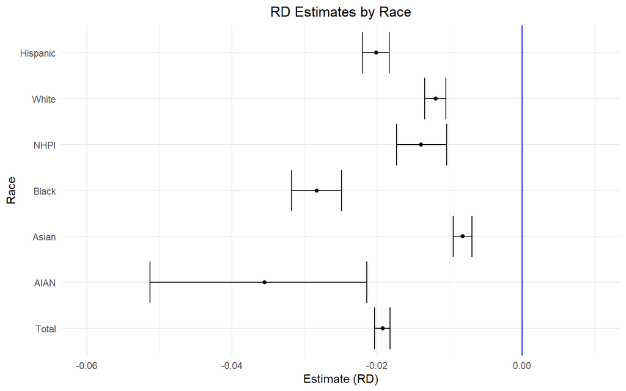

```r
# Create forest plot
p <- ggplot(output_data, aes(x = rds, y = race)) +
  geom_point() +
  geom_errorbarh(aes(xmin = lower_ci, xmax = upper_ci)) +
  labs(title = "RD Estimates by Race",
       x = "Estimate (RD)", y = "Race") +
  theme_minimal() +
  theme(plot.title = element_text(hjust = 0.5)) +
  coord_cartesian(xlim = c(-.06, 0.01)) +
    geom_vline(xintercept = 0, color = "blue")

# Print or save the plot
print(p)
```

### Interpretation

Based on the results shown above, there are differences in the relationship between black carbon exposure and preterm birth across racial groups, as reflected by the varying estimated risk differences. It appears that Amerian Indian/Alaska Natives would see the greatest reduction in the risk of preterm birth, specifically 4 fewer preterm births out of 100 births, if black carbon levels were reduced to <$0.20 \ mg/m^3$. Meanwhile, Asians would benefit least from the reductions in black carbon exposure (1 fewer preterm births out of 100 births). It is also important to note that the confidence intervals for all estimates do not include the null, which indicates that there is a protective effect of lowering black carbon among all race/ethnicity groups. Several factors could explain why certain racial groups are more or less affected by black carbon exposure, such as socioeconomic and environmental inequities, biological susceptibility, access to healthcare, and stress level.